# Incarceration Data Exploration

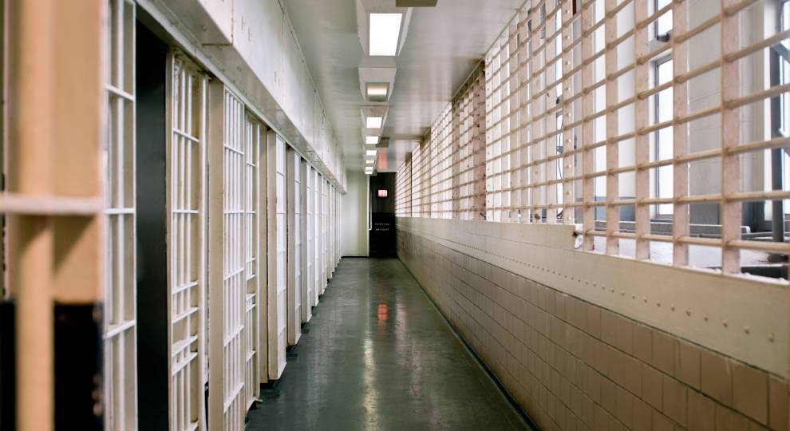

### Introduction

Data exploration on incarceration in the state of Oregon. Specifically, the incarcerated population who are on ICE hold and races represented by the incarcerated population over time across counties in Oregon. Data set was created by [Vera Institute](https://github.com/vera-institute/incarceration-trends). The following variables from the data set is the primary focus of the exploration:

1. *total_jail_from_ice*: size of incarcerated population on ICE hold
2. *black_jail_pop_rate*: incarceration rate of black population
3. *white_jail_pop_rate*: incarceration rate of white population
4. *black/aapi/latinx/white/native/other_race_jail_pop*: incarcerated popultion of a certain race
5. *black_prison_adm*: count of black individuals admitted to prison
6. *white_pop_15to64*: total white population between age of 15 to 64

##### Why these variables?

These variables provide necessary information required to understand the total incarcerated population on ICE hold in Oregon and race distribution within the incarcerated population in Oregon over time.

### Data Summary

The following results are generated based on data analysis and all null values were ignored during the process:

1. There were a total of 1772 people in jail.
2. Within the incarcerated population, there were 63 on ICE hold
3. The average ICE hold rate in Oregon over time was 1.6228717%.
4. The average percentage difference between black and white incarceration rate in 2018 in Oregon was 7.8058%.
5. There were 333 black individuals in jail in Oregon according to the most recent date in the data set.

### Trend over time chart

This chart is designed this way so that readers could easily identify the change in number of incarcerated population across all races. The x-asix documents time and the y-axis shows number of incarcerated individuals. Interestingly, the rate of change in number of incarcerated population in Oregon appears to be similar with shared peaks in 2005, 2007, and 2009 across the races represented.

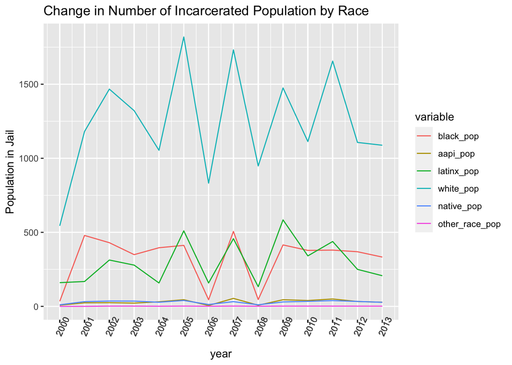

### Correlation between two varibles: White population between 15 to 64 v. Black jail admission count

The chart is designed to further explore whether or not an increasing number of white population is correlated to a higher number of black individuals being admitted in jail. A scatterplot is chosen to better demonstrate correlation. *Although there appears to be a positive correlation between white population and black individual jail admission count, we don’t have enough data to make such a conclusion.*

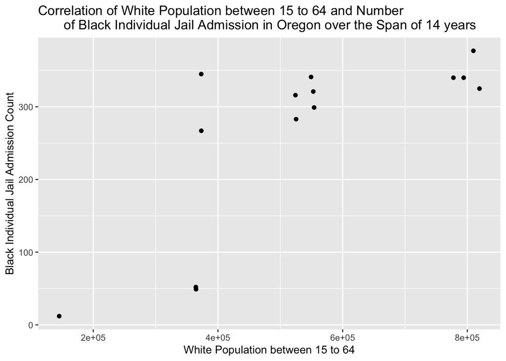

### Map: Incarcerated black population distribution in Oregon

The map is designed to show the count of incarcerated black individual in each county in Oregon. Red is chosen to represents high population and white means no available data. This graph shows that most of black incarcerated population are located in Multnomah County (where Portland is located).

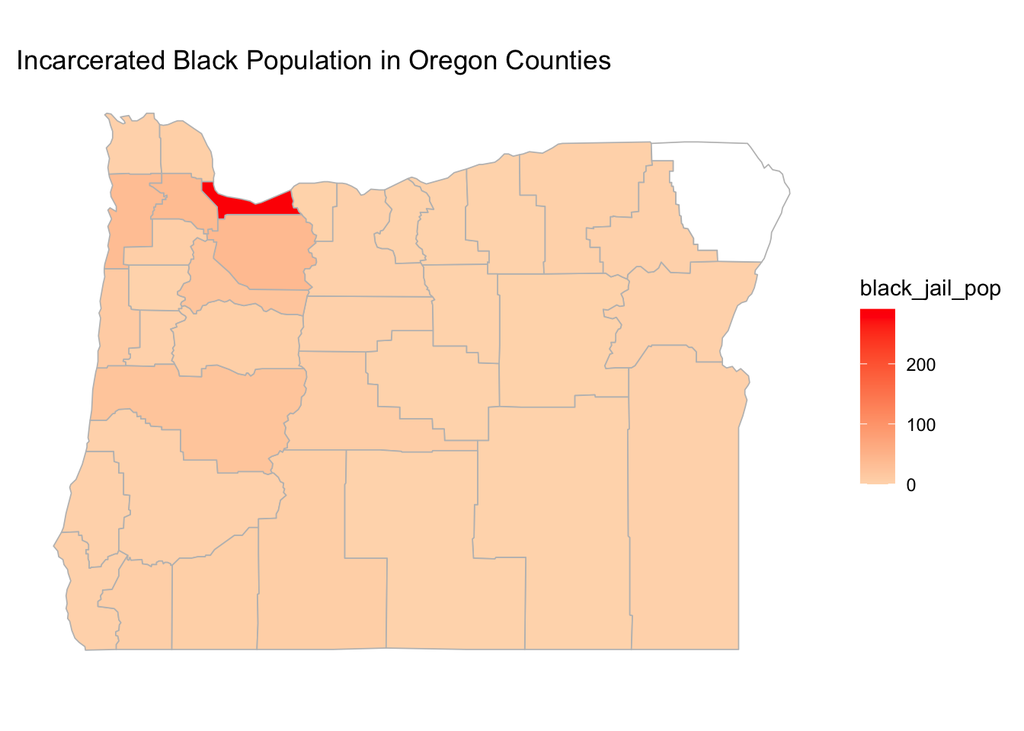